# Multidimensional Scaling

Roger Bukuru

2024-06-05

# Introduction

## What is it?

- Dimension reduction technique that represents dissimilarity data in a low-dimensional space typically for visulation
- Uses dissimalarity or similarity data as input as opposed to the original inputs i.e X like in PCA
- Scale of measurements
  - Ratio: Natural zero exists e.g height
  - Interval: Natural does not exists e.g temperature
  - Rank
    - Ordinal
    - Nominal

## Dissimilarity/Similarity Measure and Proximity Matrix

- Dissimilarity Measures
  - Minokowski distance:
    - $\delta_{ij} = (\sum_{i}^{k} |x_{ik}-x_{jk}|^{p})^\frac{1}{p}$
    - $p=1$: L1 norm
    - $p=2$: L2 norm
- Similarity Measures
  - Centered dot product
  - Correlation coefficient

## Categories

- Metric MDS
  - Classical Scaling
  - Least-squares
- Non-Metric MDS

## Classical Scaling

- Variant of metric MDS that finds the optimal low-rank/dim configuration of points such that their centered inner products match those in the original space as closely as possible
- Formula: dissimilarities > Centered Inner Products > Low Rank Config
- If the dissimilarities are Euclidean, then the solution matches that of principal components ??

### Procedure for Classical Scaling

1. Find the dissimilarities matrix $\Delta$ and do not have access to the original data matrix $X$
2. From $\Delta$ we calculate $B$ of centered dot products where $b_{ij}=x^T_ix$ for ${x_i}$ ${x_j}$ the $i-th$ and $j-th$
3. We find the rank $t$ matrix $B^*$ where the $L2$ norm from $B$ is smallest
4. The minimising configuratioon is a function of the SVD of $B= HAH$.
- $A = \frac{1}{2}\delta_{ij}^2$

### Example 1: Classical Scaling from first principles

- We perform classical scaling from first principles

```r
rm(list = ls())
library(dbplyr)
library(tidyverse)
library(ggplot2)


Delta_mat <- structure(c(0, 93, 82, 133, 93, 0, 52, 60, 82, 52, 0, 111, 133,60, 111, 0), dim = c(4L, 4L))

Delta_mat |> signif(2) # rounds number
```

```
##      [,1] [,2] [,3] [,4]
## [1,]    0   93   82  130
## [2,]   93    0   52   60
## [3,]   82   52    0  110
## [4,]  130   60  110    0
```

```r
# Calculate A matrix
# A = -0.5*delta^2
A_mat = -0.5 * Delta_mat^2
A_mat |> signif(2)
```

```
##       [,1]  [,2]  [,3]  [,4]
## [1,]     0 -4300 -3400 -8800
## [2,] -4300     0 -1400 -1800
## [3,] -3400 -1400     0 -6200
## [4,] -8800 -1800 -6200     0
```

```r
# Calculate B matrix where H = I -1/n11^T

H = diag(4) - 1/4*matrix(1,4,4)%*%t(matrix(1,4,4))
B_mat = H%*% A_mat %*% H
B_mat |> signif(3)
```

```
##        [,1]   [,2]   [,3]   [,4]
## [1,] -18600 -32000 -27600 -27200
## [2,] -32000 -36700 -34700 -29200
## [3,] -27600 -34700 -29900 -30200
## [4,] -27200 -29200 -30200 -18100
```

```r
eig_obj = eigen(B_mat)

# Calcualte the princiiapl coordiante Y= V eigen values of B

Y_mat <- eig_obj$vectors %*% diag(sqrt(eig_obj$values))
Y_mat |> signif(2)
```

```
##      [,1] [,2]  [,3] [,4]
## [1,]   63   39  -1.4  NaN
## [2,]  -18  -19 -15.0  NaN
## [3,]   25  -36  12.0  NaN
## [4,]  -69   27   7.1  NaN
```

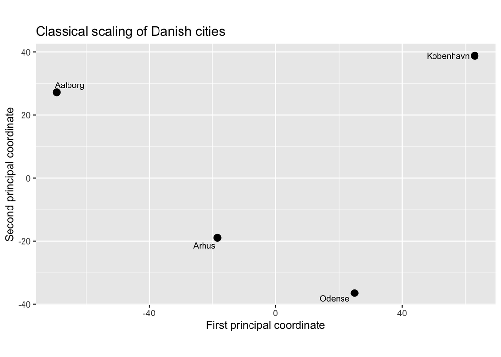

```r
plot_tbl = Y_mat %>%
           as.tibble() %>%
            mutate(
              city = c("Kobenhavn", "Arhus","Odense", "Aalborg")
            )

p = ggplot(plot_tbl, aes(V1, V2))+
    geom_point(size=3)+
    ggrepel::geom_text_repel(aes(label=city), size=3)+
    coord_equal()+
    xlab("First principal coordinate") +  # Label for the x-axis
    ylab("Second principal coordinate") +  # Label for the y-axis
    ggtitle("Classical scaling of Danish cities")  # Main title of the plot
p
```

### Example II

- We perform classical scaling from first principles

```r
rm(list = ls())
library(dbplyr)
library(tidyverse)
library(ggplot2)

if (!requireNamespace("remotes", quietly = TRUE)) {
install.packages("remotes")
}
if (!requireNamespace("DataTidy24STA5069Z", quietly = TRUE)) {
remotes::install_github("MiguelRodo/DataTidy24STA5069Z")
}
data("data_tidy_sa_distance", package = "DataTidy24STA5069Z")

# Step 1 calculate or obtain the proxmity matrix

Delta_mat = as.matrix(data_tidy_sa_distance)/1e3 # Scal and the data

Delta_mat[1:3, 1:3] |> signif(2)
```

```
##      Bloemfontein CapeTown Durban
## [1,]         0.00      1.0   0.63
## [2,]         1.00      0.0   1.70
## [3,]         0.63      1.7   0.00
```

```r
n = nrow(Delta_mat)
# Calculate A

A_mat = -0.5 * Delta_mat^2
A_mat[1:3, 1:3] |> signif(2)
```

```
##      Bloemfontein CapeTown Durban
## [1,]          0.0     -0.5   -0.2
## [2,]         -0.5      0.0   -1.4
## [3,]         -0.2     -1.4    0.0
```

```r
# Calculate B = HAH where H = I-1/n11^T

H_mat = diag(n) - 1/n*matrix(1,n,n)
B_mat = H_mat%*%A_mat%*%H_mat
B_mat[1:3,1:3] |> signif(3)
```

```
##          [,1]    [,2]    [,3]
## [1,]  0.00789  0.0939 -0.0199
## [2,]  0.09390  1.1800 -0.6170
## [3,] -0.01990 -0.6170  0.3470
```

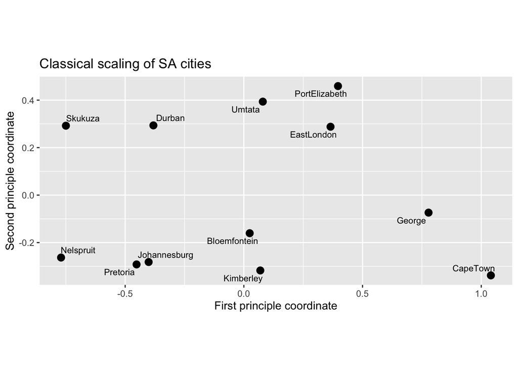

```r
eigen_obj = eigen(B_mat)
Y_mat = eigen_obj$vectors%*%diag(sqrt(eigen_obj$values))

plot_tbl = Y_mat %>%
           as.tibble() %>%
            mutate(
              city = data_tidy_sa_distance |> colnames()
            )

p = ggplot(plot_tbl, aes(V1, V2))+
    geom_point(size=3)+
    ggrepel::geom_text_repel(aes(label=city), size=3)+
    coord_equal()+
    xlab("First principle coordinate") +  # Label for the x-axis
    ylab("Second principle coordinate") +  # Label for the y-axis
    ggtitle("Classical scaling of SA cities")  # Main title of the plot
p
```

## Least Squares Scaling

### Least-Squares Optimisation Algorithm

#### Example I:

- We perform least-squares scaling from first principles
- But use the `cmds` package for classical scaling for initial `Y`
- We make use of constant weights
- Use an identify function as our $f$ monotonic function

```r
rm(list = ls())
library(dbplyr)
library(tidyverse)
library(ggplot2)

if (!requireNamespace(
"smacof", quietly = TRUE
)) {
install.packages("smacof")
}
data(
"kinshipscales", package = "smacof"
)
data(
"kinshipdelta", package = "smacof")

kinshipscales [1:4, ]
```

```
##          Gender Generation Degree
## Aunt          2         -1      3
## Brother       1          0      2
## Cousin       NA          0      4
## Daughter      2          1      1
```

```r
kinshipdelta[1:6, 1:6]
```

```
##               Aunt Brother Cousin Daughter Father Granddaughter
## Aunt             0      79     53       59     73            57
## Brother         79       0     67       62     38            75
## Cousin          53      67      0       74     77            74
## Daughter        59      62     74        0     57            46
## Father          73      38     77       57      0            79
## Granddaughter   57      75     74       46     79             0
```

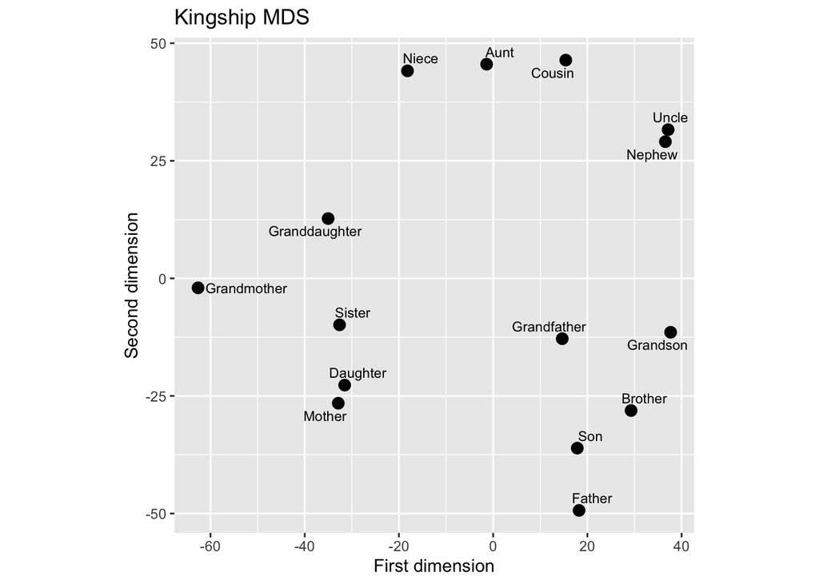

```r
# First, we write the stress function
calc_stress = function(y, delta_mat, dim=2){ # dim = specificies the number of dimension we reduced the dimension
  Y_mat = matrix(y, ncol=dim)
  D_mat = as.matrix(dist(Y_mat))
  error_mat = ((D_mat - delta_mat)^2)[lower.tri(D_mat)] # using identity monotonic function f
  weight = 1 / sum(D_mat[lower.tri(D_mat)]^2) # why D-mat and not
  sum(error_mat) * weight
}
# We generate an initial configuration using classical scaling:
y_vec = cmdscale(kinshipdelta) |> as.vector() # by default cmdscale returns transformed data in 2 dimensions
# we optimise
optim_obj = optim(y_vec, calc_stress, delta_mat = kinshipdelta)
Y_mat = matrix(optim_obj$par, ncol = 2)

plot_tbl = Y_mat %>%
           as.tibble() %>%
           mutate(
             familial_term = kinshipdelta |> colnames()
           )
p = ggplot(plot_tbl, aes(V1,V2))+
    geom_point(size = 3)+
    ggrepel::geom_text_repel(
      aes(label = familial_term),
      size = 3
      )+
  coord_equal()+
    xlab("First dimension") +  # Label for the x-axis
    ylab("Second dimension") +  # Label for the y-axis
    ggtitle("Kingship MDS")  # Main title of the plot
p
```

#### Example II:

- Here we use the `mds` package to perform least-squares scaling
- Use constant weights
- Use an identity monotonic function

```r
rm(list = ls())
library(dbplyr)
library(tidyverse)
library(ggplot2)
library(smacof)

set.seed(34)
data("data_tidy_morse", package = "DataTidy24STA5069Z")
data_tidy_morse[1:8, 1:8]
```

```
## # A tibble: 8 × 8
##       A     B     C     D     E     F     G     H
##   <dbl> <dbl> <dbl> <dbl> <dbl> <dbl> <dbl> <dbl>
## 1  0.92  0.04  0.06  0.13  0.03  0.14  0.1   0.13
## 2  0.05  0.84  0.37  0.31  0.05  0.28  0.17  0.21
## 3  0.04  0.38  0.87  0.17  0.04  0.29  0.13  0.07
## 4  0.08  0.62  0.17  0.88  0.07  0.23  0.4   0.36
## 5  0.06  0.13  0.14  0.06  0.97  0.02  0.04  0.04
## 6  0.04  0.51  0.33  0.19  0.02  0.9   0.1   0.29
## 7  0.09  0.18  0.27  0.38  0.01  0.14  0.9   0.06
## 8  0.03  0.45  0.23  0.25  0.09  0.32  0.08  0.87
```

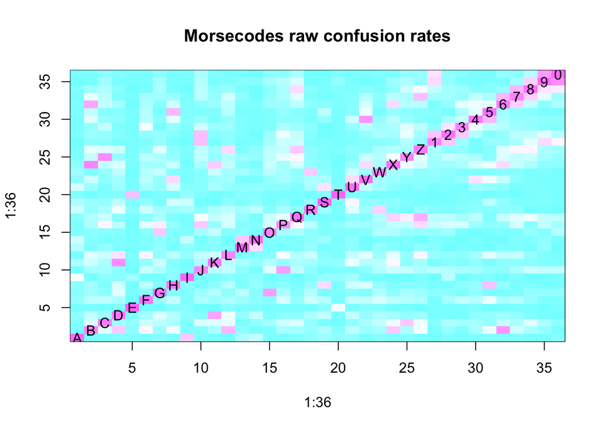

```r
morse_mat <- as.matrix(data_tidy_morse)
image(
1:36, 1:36, morse_mat,
main = "Morsecodes raw confusion rates", col = cm.colors(36, 1)
)
cn_vec <- colnames(data_tidy_morse)
cn_vec <- substr(cn_vec, nchar(cn_vec), nchar(cn_vec))
text(1:36, 1:36, cn_vec)
```

```r
# We generate the symmetric dissimilarities

row_mat <- matrix(rep(diag(morse_mat), each = ncol(morse_mat)), byrow = TRUE, nrow = nrow(morse_mat))
morse_mat_tilde <- row_mat + t(row_mat) - morse_mat - t(morse_mat)
morse_mat_tilde[1:3, 1:3]
```

```
##         A    B    C
## [1,] 0.00 1.67 1.69
## [2,] 1.67 0.00 0.96
## [3,] 1.69 0.96 0.00
```

```r
mds_obj <- mds(
delta = morse_mat_tilde, # dissimilarities
ndim = 2, # desired dimension of configuration
type = "ratio", # type of dissimilarity
init = "torgerson" # initialise with classical scaling
)

# Extract the coordinates

mds_obj[["conf"]][1:5, ]
```

```
##             D1          D2
## 1  0.749122600  0.43153708
## 2  0.032926713 -0.43546664
## 3 -0.187375174 -0.15147460
## 4  0.443400707 -0.01790054
## 5 -0.002802397  0.97857494
```

```r
# Per-point contribution to total stress:

mds_obj[["spp"]][1:5]
```

```
##        1        2        3        4        5
## 3.313617 1.686036 2.377347 2.620053 4.700401
```

#### Evaluating MDS Results

Random in results

- MDS will be sensitive to the initial configuration.
  - Even if the plots are similar in terms of inter-point proximity, their orientation may be different - especially if using a random initialisation
  - At a minimum, set the seed. One can also choose the configuration that minimises stress.
- Stress is a measure of how well the distances between points in the lower-dimensional space (the MDS configuration) match the original dissimilarities (or distances) in the high-dimensional space.
  - What does the per-point contribution in total stress mean ?
    - High contributions to stress mean that these are far from the original dissimilarities
    - Low contributions to stress mean that these are far near the original dissimilarities and therefore are good estimations in the lower dimensional space

#### Sammon Mapping

- We downweight larger original distances ($w_{ij} = \frac{1}{\delta_{ij}\sum_{i<j}\delta_{ij}}$)

```r
rm(list = ls())
library(dbplyr)
library(tidyverse)
library(ggplot2)
library(smacof)

#MASS::sammon(d, y = cmdscale(d,k), k = 2, niter = 1e3, trace = TRUE, magic = 0.2, tol = 1e-4)

set.seed(12394)
data("data_tidy_sa_distance", package = "DataTidy24STA5069Z")
sammon_obj <- MASS::sammon(data_tidy_sa_distance |> as.matrix())
```

```
## Initial stress        : 0.08369
## stress after  10 iters: 0.03675, magic = 0.225
## stress after  20 iters: 0.03548, magic = 0.500
## stress after  30 iters: 0.03547, magic = 0.500
```

[figure not shown]

```r
plot_tbl <- sammon_obj$points |>
tibble::as_tibble() |>
dplyr::mutate(
city = data_tidy_sa_distance |>
colnames()
)
p <- ggplot(plot_tbl, aes(V1, V2)) +
geom_point(size = 3) +
ggrepel::geom_text_repel(
aes(label = city), size = 3
) +
  coord_equal()+
  xlab("First dimension") +  # Label for the x-axis
  ylab("Second dimension") +  # Label for the y-axis
  ggtitle("Kingship MDS")  # Main title of the plot
p
```

## Non-Metric MDS

- In non-metric MDS, we do not preserve the actual dissimilarities, but only the ranks of the dissimularities
- Dissimilarities can be strictly ordered from smallest to largest $\delta_{i_1,j_1} < \delta_{i_2,j_2}< ... <\delta_{i_m,j_m}$

Where $(i_1,j_1)$, $(i_m,jm)$ indicates the pair of entities having the smallest and largest dissimilarities respectively - Nonmetric scaling finds a lower-dimensional space such that the distances $d_{i_1,j_1} < d_{i_2,j_2}< ... <d_{i_m,j_m}$ matches exactly the ordering of the dissimilarities. - Since a plot of the configuration distances $d_{ij}$ against their rank order does not necessarily produce a monotonically looking scatterplot, thereby violating the monotonic condition we approximate the $d$ by $\hat{d}$.

# Practice Exercises

## Question 1

For this exercise we will be using the cities data that is found in the psych package in R. Run the following lines of code to obtain the dissimilarity matrix that we will work with. library(psych) data(cities) cities

- 1. Using the first 4 (four) cities, ATL, BOS, ORD and DCA. Perform the classical scaling algorithm by first principals to obtain the principals coordinates. Plot the principal coordinates in 2 dimensions. You can use R to create matrices and perform the Eigen value decomposition.

```r
rm(list=ls())
library(ggplot2)
library(ggrepel)
library(psych)
library(psychTools)
data(cities)
head(cities)
```

```
##      ATL  BOS  ORD  DCA  DEN  LAX  MIA  JFK  SEA  SFO  MSY
## ATL    0  934  585  542 1209 1942  605  751 2181 2139  424
## BOS  934    0  853  392 1769 2601 1252  183 2492 2700 1356
## ORD  585  853    0  598  918 1748 1187  720 1736 1857  830
## DCA  542  392  598    0 1493 2305  922  209 2328 2442  964
## DEN 1209 1769  918 1493    0  836 1723 1636 1023  951 1079
## LAX 1942 2601 1748 2305  836    0 2345 2461  957  341 1679
```

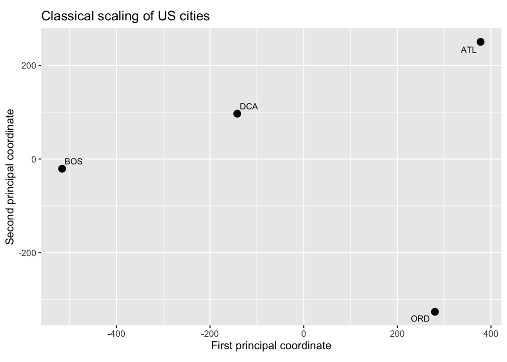

```r
classical_scaling_first_principals = function(numberOfCities=4, rotateMap = FALSE){

rotateFactor = -1
if(!rotateMap){
  rotateFactor  = 1
}
# Calculate the A matrix
delta_mat = as.matrix(cities[1:numberOfCities, 1:numberOfCities])
n = nrow(delta_mat)
# A = -0.5*sqrt(delta_mat^2)
A_mat = -0.5*delta_mat^2


# Calculate H_mat
H_mat = diag(1,n) - 1/n*matrix(1,n,n) #%*%t(matrix(1,n,n))

B_mat = H_mat%*%A_mat%*%H_mat

eigen_decom = eigen(B_mat)

# Y = V(eigenvectors) %*% diag(sqrt(eigenvalues))

# Calcualte the princiiapl coordiante Y= V eigen values of B

Y_mat = eigen_decom$vectors %*% diag(sqrt(eigen_decom$values))


plot_tbl = Y_mat %>%
           as.tibble() %>%
            mutate(
              city = colnames(delta_mat)
            )

p = ggplot(plot_tbl, aes(rotateFactor*V1, rotateFactor*V2))+
    geom_point(size=3)+
    ggrepel::geom_text_repel(aes(label=city), size=3)+
    coord_equal()+
    xlab("First principal coordinate") +  # Label for the x-axis
    ylab("Second principal coordinate") +  # Label for the y-axis
    ggtitle("Classical scaling of US cities")  # Main title of the plot
p
}
classical_scaling_first_principals()
```

2. Use the function cmdscale in R to check check your answer in part (a).

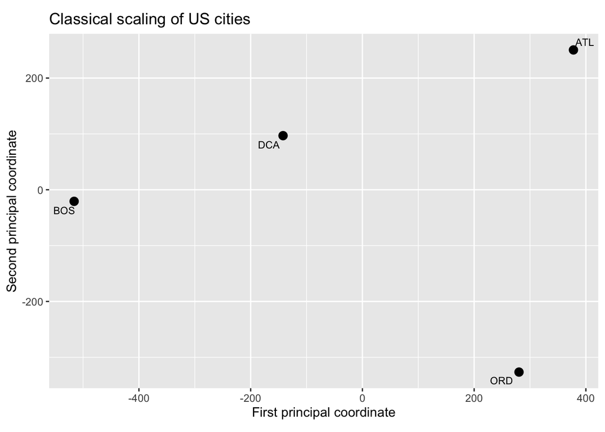

```r
delta_mat = as.matrix(cities[1:4, 1:4])
eigen_decom = cmdscale(delta_mat, k=2, eig = TRUE, list. = TRUE)
Y_mat = eigen_decom$points

plot_tbl = Y_mat %>%
           as.tibble() %>%
            mutate(
              city = c("ATL", "BOS","ORD", "DCA")
            )

p = ggplot(plot_tbl, aes(V1, V2))+
    geom_point(size=3)+
    ggrepel::geom_text_repel(aes(label=city), size=3)+
    coord_equal()+
    xlab("First principal coordinate") +  # Label for the x-axis
    ylab("Second principal coordinate") +  # Label for the y-axis
    ggtitle("Classical scaling of US cities")  # Main title of the plot
p
```

3. Perform the classical scaling algorithm to the entire dissimilarity matrix and obtain the principal coordinates. Plot the resulting coordinates in 2 dimensions.

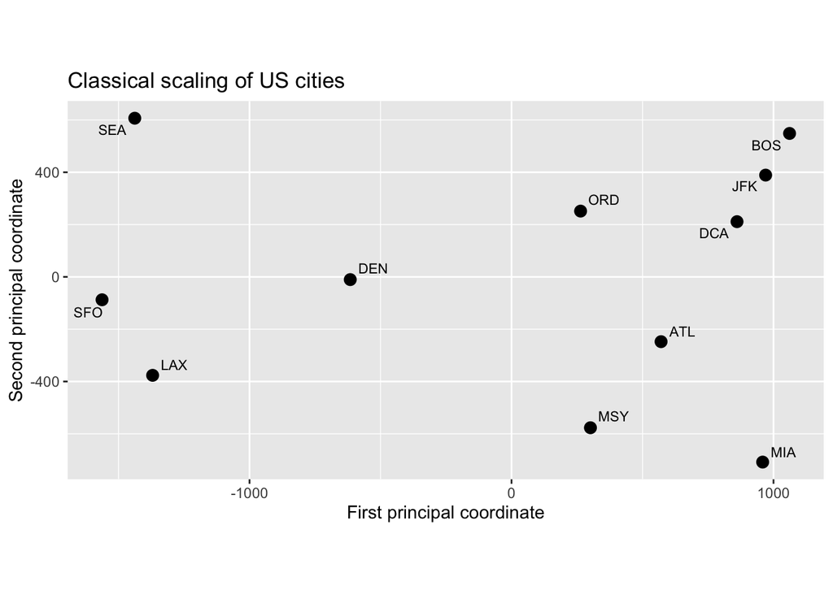

```r
classical_scaling_first_principals(11, TRUE)
```

## Question 2

Question 2

- 1. Use the mds() function – in the smacof package – to perform metric multidimensional scaling. Locate the cities in t=2 dimensions, starting with a classical scaling solution as the initial configuration.

### From First Principles

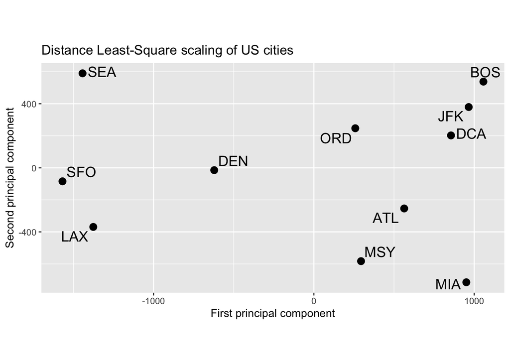

```r
rm(list = ls())
library(ggplot2)
library(smacof)

data(cities)
proximity_matrix = cities
stress_func = function(y, delta_mat, dim=2){
  Y_mat = matrix(y, ncol=dim)
  D_mat = as.matrix(dist(Y_mat))
  # Identity f function
  f = delta_mat
  error_mat = ((D_mat-f)^2)[lower.tri(D_mat)]
  # constant weight
  weight_mat = 1/sum(delta_mat[lower.tri(D_mat)]^2)

  weight_mat*sum(error_mat)

}

y_vec = cmdscale(proximity_matrix, k =2)


min_stress_fun = optim(y_vec, stress_func, delta_mat = proximity_matrix)

Y_mat = matrix(min_stress_fun$par, ncol = 2)

fitted_configs = Y_mat %>%
                 as.tibble() %>%
                  mutate(
                    city = colnames(proximity_matrix)
                  )


ggplot(fitted_configs, aes(-V1,-V2), alpha = 0.5 , color = "blue", size = 10 )+
      geom_point(size=3) +
      geom_text_repel(
       aes(label = city), size = 5
     ) +
    labs(x = "First principal component", y = "Second principal component", title = "Distance Least-Square scaling of US cities") +
    coord_equal()
```

```r
min_stress_fun$value
```

```
## [1] 3.331485e-06
```

[figure not shown]

```r
n = nrow(proximity_matrix)
weight_mat = matrix(0, ncol=n, nrow=n)
constant_weight = 1/sum(proximity_matrix[lower.tri(proximity_matrix)]^2)
weight_mat[lower.tri(weight_mat)] = constant_weight

metric_mds = mds(proximity_matrix, ndim=2, init = "torgerson", weightmat = weight_mat, type = "ratio")
fitted_configs_2 = metric_mds$conf %>%
                 as.tibble() %>%
                  mutate(
                    city = colnames(proximity_matrix)
                  )

ggplot(fitted_configs_2, aes(-1*D1, -1*D2))+
    geom_point(size=3)+
    ggrepel::geom_text_repel(aes(label=city), size=3)+
    coord_equal()+
    xlab("First principal coordinate") +  # Label for the x-axis
    ylab("Second principal coordinate") +  # Label for the y-axis
    ggtitle("Classical scaling of Danish cities")  # Main title of the plot
```

- 2. Which of the 11 cities has the poorest fit? Explain your answer.

```r
metric_mds$stress
```

```
## [1] 0.00206447
```

```r
metric_mds$spp
```

```
##        ATL        BOS        ORD        DCA        DEN        LAX        MIA
##  2.6440777  7.9040554  1.7018267  0.7010979  1.5993119 20.1502872 12.2196378
##        JFK        SEA        SFO        MSY
##  2.3776837 33.4778124 13.6394028  3.5848066
```

Observing the per point stress points we note that SEA is the city with the poorest fit as it has the highest stress point of 33.48%, this means that it has been matched the poorest relative to it’s original dissimilarities as it has the highest contribution to the stress value of 0.00206447. Could indicate an outlier or it’s dissimilarities with the other cities might be inconsistent with the rest of the data

- 3. Plot the 2D multidimensional scaling configuration and compare this the locations of the cities on a map from the atlas.

From the map below we observe that the the low-dimensional map is a good representation of the Atlas mapping indicating the actual positions of the cities. We further support this with the relavtively low stress value of 0.00206447, indicating that the points in the low-dim have been matched relatively well with their original dissimilarities.

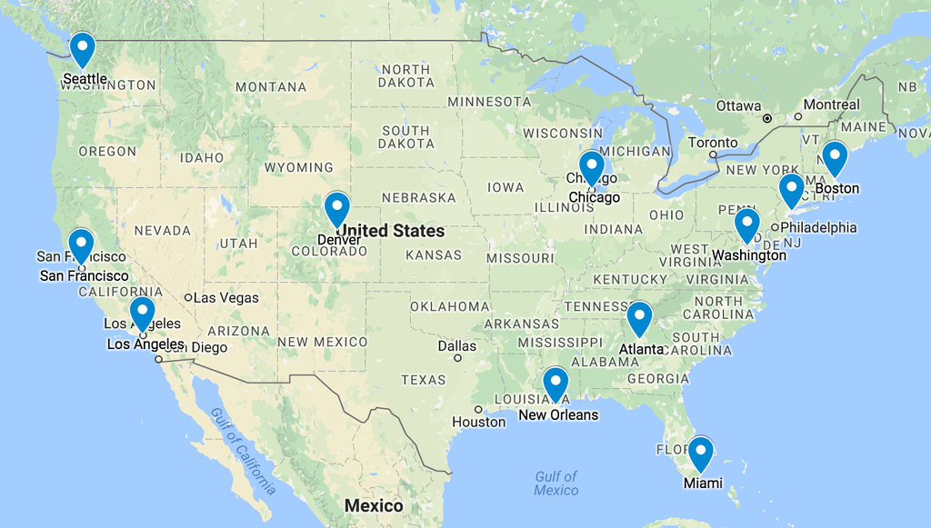

US Cities Map

2. Repeat the analysis in part (a) using a random starting solution. How does the different initial configuration change the location of the cities in the 2D configuration?

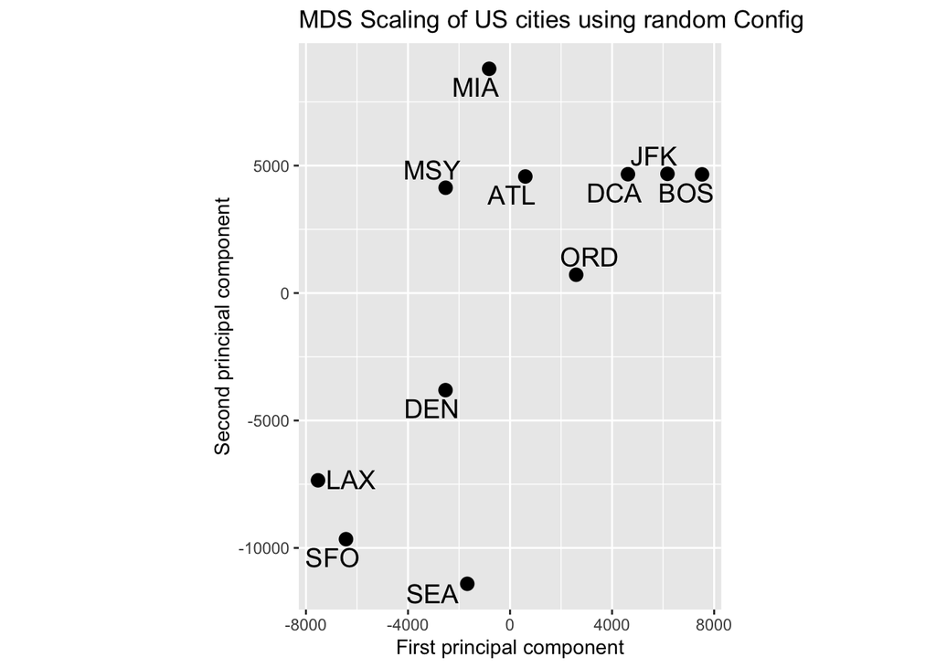

```r
metric_mds_random = mds(delta = proximity_matrix, ndim=2, init = "random", type = "ratio", weightmat = weight_mat)


fitted_configs_random = metric_mds_random$conf %>%
                 as.tibble() %>%
                  mutate(
                    city = colnames(proximity_matrix)
                  )
ggplot(fitted_configs_random, aes(-D1,-D2), alpha = 0.5 , color = "blue", size = 10 )+
      geom_point(size=3) +
      geom_text_repel(
       aes(label = city), size = 5
     ) +
    labs(x = "First principal component", y = "Second principal component", title = "MDS Scaling of US cities using random Config") +
    coord_equal()
```